# Scraping data from Twitter’s REST API

Pablo Barbera

We’ll now turn to a different type of Twitter data – static data, either recent tweets or user-level information. This type of data can be retrieved with Twitter’s REST API. We will use the `tweetscores` package here – this is a package that I created to facilitate the collection and analysis of Twitter data.

### Searching recent tweets

It is possible to download recent tweets, but only up those less than 7 days old, and in some cases not all of them.

```r
load("~/my_oauth")
library(tweetscores)
library(streamR)
searchTweets(q=c("impeachment", "trump"),
  filename="data/recent-impeachment-tweets.json",
  n=1000, until="2019-11-09",
  oauth=my_oauth)
```

```
## 100 tweets. Max id: 1192954954266415104
```

```
## 164 hits left
```

```
## 200 tweets. Max id: 1192954908284194816
```

```
## 163 hits left
```

```
## 300 tweets. Max id: 1192954848435523584
```

```
## 162 hits left
```

```
## 400 tweets. Max id: 1192954797890187264
```

```
## 161 hits left
```

```
## 500 tweets. Max id: 1192954742927962112
```

```
## 160 hits left
```

```
## 600 tweets. Max id: 1192954696442318848
```

```
## 159 hits left
```

```
## 700 tweets. Max id: 1192954639139901440
```

```
## 158 hits left
```

```
## 800 tweets. Max id: 1192954586476109824
```

```
## 157 hits left
```

```
## 900 tweets. Max id: 1192954534613725184
```

```
## 156 hits left
```

```
## 1000 tweets. Max id: 1192954482663006208
```

```r
tweets <- parseTweets("data/recent-impeachment-tweets.json")
```

```
## 1000 tweets have been parsed.
```

What are the most popular hashtags?

```r
library(stringr)
ht <- str_extract_all(tweets$text, '#[A-Za-z0-9_]+')
ht <- unlist(ht)
head(sort(table(ht), decreasing = TRUE))
```

```
## ht
## #Impeachment     #FoxNews    #BREAKING   #Extortion       #Trump
##            6            5            4            4            4
##    #Goldberg
##            3
```

You can check the documentation about the options for string search [here](https://dev.twitter.com/rest/public/search).

### Extracting users’ profile information

This is how you would extract information from user profiles:

```r
wh <- c("realDonaldTrump", "POTUS", "VP", "FLOTUS")
users <- getUsersBatch(screen_names=wh,
                       oauth=my_oauth)
```

```
## 1--4 users left
```

```r
str(users)
```

```
## 'data.frame':    4 obs. of  9 variables:
##  $ id_str         : chr  "822215679726100480" "25073877" "818876014390603776" "818910970567344128"
##  $ screen_name    : chr  "POTUS" "realDonaldTrump" "FLOTUS" "VP"
##  $ name           : chr  "President Trump" "Donald J. Trump" "Melania Trump" "Vice President Mike Pence"
##  $ description    : chr  "45th President of the United States of America, @realDonaldTrump. Tweets archived: https://t.co/eVVzoBb3Zr" "45th President of the United States of America\U0001f1fa\U0001f1f8" "This account is run by the Office of First Lady Melania Trump. Tweets may be archived. More a…
##  $ followers_count: int  27085046 66738550 12606010 8075413
##  $ statuses_count : int  7718 46039 736 7789
##  $ friends_count  : int  39 47 7 13
##  $ created_at     : chr  "Thu Jan 19 22:54:28 +0000 2017" "Wed Mar 18 13:46:38 +0000 2009" "Tue Jan 10 17:43:50 +0000 2017" "Tue Jan 10 20:02:44 +0000 2017"
##  $ location       : chr  "Washington, D.C." "Washington, DC" "Washington, D.C." "Washington, D.C."
```

Which of these has the most followers?

```r
users[which.max(users$followers_count),]
```

```
##     id_str     screen_name            name
## 2 25073877 realDonaldTrump Donald J. Trump
##                                                          description
## 2 45th President of the United States of America\U0001f1fa\U0001f1f8
##   followers_count statuses_count friends_count
## 2        66738550          46039            47
##                       created_at       location
## 2 Wed Mar 18 13:46:38 +0000 2009 Washington, DC
```

```r
users$screen_name[which.max(users$followers_count)]
```

```
## [1] "realDonaldTrump"
```

Download up to 3,200 recent tweets from a Twitter account:

```r
getTimeline(filename="data/realDonaldTrump.json", screen_name="realDonaldTrump", n=1000, oauth=my_oauth)
```

```
## 199 tweets. Max id: 1191708046126399488
```

```
## 888 hits left
```

```
## 399 tweets. Max id: 1189555451274379265
```

```
## 887 hits left
```

```
## 599 tweets. Max id: 1186982949180317697
```

```
## 886 hits left
```

```
## 798 tweets. Max id: 1184810906942935040
```

```
## 885 hits left
```

```
## 998 tweets. Max id: 1182288206806560769
```

```
## 884 hits left
```

```
## 1198 tweets. Max id: 1180521553932488705
```

What are the most common hashtags?

```r
tweets <- parseTweets("data/realDonaldTrump.json")
```

```
## 1198 tweets have been parsed.
```

```r
ht <- str_extract_all(tweets$text, '#[A-Za-z0-9_]+')
ht <- unlist(ht)
head(sort(table(ht), decreasing = TRUE))
```

```
## ht
##          #KAG2020             #MAGA      #impeachment                #1
##                11                10                 6                 4
##        #GeauxVote #TrumpMinneapolis
##                 3                 3
```

### Building friend and follower networks

Download friends and followers:

```r
followers <- getFollowers("uscpoir",
    oauth=my_oauth)
```

```
## 14 API calls left
```

```
## 361 followers. Next cursor: 0
```

```
## 13 API calls left
```

```r
friends <- getFriends("uscpoir",
    oauth=my_oauth)
```

```
## 10 API calls left
```

```
## 152 friends. Next cursor: 0
```

```
## 9 API calls left
```

What are the most common words that friends of the uscpoir account use to describe themselves on Twitter?

```r
# extract profile descriptions
users <- getUsersBatch(ids=friends, oauth=my_oauth)
```

```
## 1--152 users left
```

```
## 2--52 users left
```

```r
# create table with frequency of word use
library(quanteda)
tw <- corpus(users$description[users$description!=""])
dfm <- dfm(tw, remove=c(stopwords("english"), stopwords("spanish"),
                                 "t.co", "https", "rt", "rts", "http"),
           remove_punct=TRUE)
topfeatures(dfm, n = 30)
```

```
##     political       science           usc      politics      research
##            46            37            35            27            18
##           phd      @uscpoir    university        public    california
##            17            16            16            15            15
##      official          news     candidate     assistant     professor
##            15            14            13            12            12
##        policy            us      southern        social       journal
##            12            12            12            12            11
##       twitter       student       account        school          ph.d
##            11            11            10            10            10
##       studies international         study         media          @usc
##            10             9             9             9             9
```

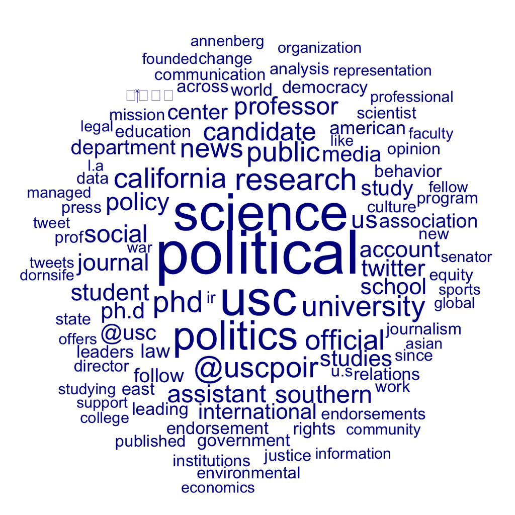

```r
# create wordcloud
par(mar=c(0,0,0,0))
textplot_wordcloud(dfm, rotation=0, min_size=1, max_size=5, max_words=100)
```

### Estimating ideology based on Twitter networks

The `tweetscores` package also includes functions to replicate the method developed in the Political Analysis paper [**Birds of a Feather Tweet Together. Bayesian Ideal Point Estimation Using Twitter Data**](https://doi.org/10.1093/pan/mpu011). For an application of this method, see also [this Monkey Cage blog post](http://www.washingtonpost.com/blogs/monkey-cage/wp/2015/06/16/who-is-the-most-conservative-republican-candidate-for-president/).

```r
# download list of friends for an account
user <- "DonaldJTrumpJr"
friends <- getFriends(user, oauth=my_oauth)
```

```
## 9 API calls left
```

```
## 1380 friends. Next cursor: 0
```

```
## 8 API calls left
```

```r
# estimating ideology with correspondence analysis method
(theta <- estimateIdeology2(user, friends, verbose=FALSE))
```

```
## DonaldJTrumpJr follows 144 elites: ABC, AEI, AlbertBrooks, AllenWest, AmbJohnBolton, andersoncooper, AndreaTantaros, AnnCoulter, AP, AriFleischer, azizansari, BBCBreaking, BBCWorld, benshapiro, BillHemmer, BillyHallowell, BreakingNews, BreitbartNews, BretBaier, brithume, BuzzFeed, ByronYork, Char…
```

```
## [1] 1.448396
```

```r
# download list of friends for an account
user <- "realDonaldTrump"
friends <- getFriends(user, oauth=my_oauth)
```

```
## 8 API calls left
```

```
## 47 friends. Next cursor: 0
```

```
## 7 API calls left
```

```r
# estimating ideology with correspondence analysis method
(theta <- estimateIdeology2(user, friends, verbose=FALSE))
```

```
## realDonaldTrump follows 10 elites: DRUDGE_REPORT, ericbolling, foxandfriends, IngrahamAngle, jim_jordan, oreillyfactor, piersmorgan, Reince, seanhannity, TuckerCarlson
```

```
## [1] 1.820566
```

### Other types of data

The REST API offers also a long list of other endpoints that could be of use at some point, depending on your research interests.

1. You can search users related to specific keywords:

```r
users <- searchUsers(q="uscpoir", count=100, oauth=my_oauth)
users$screen_name[1:10]
```

```
##  [1] "uscpoir"         "p_barbera"       "kelly_zvobgo"
##  [4] "KyleSRapp"       "SuzieMulesky"    "sbonillab"
##  [7] "NicholasNapolio" "thereanders"     "tjamieso1"
## [10] "honey_coombs"
```

2. If you know the ID of the tweets, you can download it directly from the API. This is useful because tweets cannot be redistributed as part of the replication materials of a published paper, but the list of tweet IDs can be shared:

```r
# Downloading tweets when you know the ID
getStatuses(ids=c("474134260149157888", "266038556504494082"),
            filename="data/old-tweets.json",
            oauth=my_oauth)
```

```
## 899 API calls left
```

```
## 2 tweets left.
```

```
## 0 tweets left.
```

```
## 898 API calls left
```

```r
parseTweets("data/old-tweets.json")
```

```
## 2 tweets have been parsed.
```

```
##                                                             text
## 1 Are you allowed to impeach a president for gross incompetence?
## 2           The electoral college is a disaster for a democracy.
##   retweet_count favorite_count favorited truncated             id_str
## 1        226962         209952     FALSE     FALSE 474134260149157888
## 2        142498         111447     FALSE     FALSE 266038556504494082
##   in_reply_to_screen_name
## 1                      NA
## 2                      NA
##                                                                                 source
## 1 <a href="http://twitter.com/download/android" rel="nofollow">Twitter for Android</a>
## 2                   <a href="http://twitter.com" rel="nofollow">Twitter Web Client</a>
##   retweeted                     created_at in_reply_to_status_id_str
## 1     FALSE Wed Jun 04 10:23:11 +0000 2014                        NA
## 2     FALSE Wed Nov 07 04:45:09 +0000 2012                        NA
##   in_reply_to_user_id_str lang listed_count verified       location
## 1                      NA   en       110639     TRUE Washington, DC
## 2                      NA   en       110639     TRUE Washington, DC
##   user_id_str
## 1    25073877
## 2    25073877
##                                                          description
## 1 45th President of the United States of America\U0001f1fa\U0001f1f8
## 2 45th President of the United States of America\U0001f1fa\U0001f1f8
##   geo_enabled                user_created_at statuses_count
## 1        TRUE Wed Mar 18 13:46:38 +0000 2009          46039
## 2        TRUE Wed Mar 18 13:46:38 +0000 2009          46039
##   followers_count favourites_count protected                user_url
## 1        66738567                6     FALSE https://t.co/OMxB0x7xC5
## 2        66738567                6     FALSE https://t.co/OMxB0x7xC5
##              name time_zone user_lang utc_offset friends_count
## 1 Donald J. Trump        NA        NA         NA            47
## 2 Donald J. Trump        NA        NA         NA            47
##       screen_name country_code country place_type full_name place_name
## 1 realDonaldTrump           NA      NA         NA        NA         NA
## 2 realDonaldTrump           NA      NA         NA        NA         NA
##   place_id place_lat place_lon lat lon expanded_url url
## 1       NA       NaN       NaN  NA  NA           NA  NA
## 2       NA       NaN       NaN  NA  NA           NA  NA
```

3. Lists of Twitter users, compiled by other users, are also accessible through the API.

```r
# download user information from a list
MCs <- getList(list_name="new-members-of-congress",
               screen_name="cspan", oauth=my_oauth)
```

```
## 894 API calls left
```

```
## 20 users in list. Next cursor: 5504177645515399168
```

```
## 893 API calls left
```

```
## 40 users in list. Next cursor: 5361732962332446720
```

```
## 892 API calls left
```

```
## 60 users in list. Next cursor: 4611686019261061818
```

```
## 891 API calls left
```

```
## 80 users in list. Next cursor: 4611686018645680191
```

```
## 890 API calls left
```

```
## 100 users in list. Next cursor: 4611686018453445113
```

```
## 889 API calls left
```

```
## 109 users in list. Next cursor: 0
```

```
## 888 API calls left
```

```r
head(MCs)
```

```
##             id              id_str            name    screen_name
## 1 1.029094e+18 1029094268542099457    Lance Gooden    Lancegooden
## 2 9.917210e+17  991721030631780354    Jahana Hayes  JahanaHayesCT
## 3 9.864236e+17  986423555025002497     Bryan Steil     BryanSteil
## 4 9.772474e+17  977247448820305920     Joe Morelle    votemorelle
## 5 9.693281e+17  969328139485802496      John Joyce JohnJoyceForPA
## 6 9.649970e+17  964996994623311874 Kelly Armstrong   Armstrong_ND
##            location
## 1       Terrell, TX
## 2     Waterbury, CT
## 3
## 4   Irondequoit, NY
## 5 Pennsylvania, USA
## 6
##                                                                                                                                                       description
```

[output cut: 20 more lines]

This is also useful if e.g. you’re interested in compiling lists of journalists, because media outlets offer these lists in their profiles.

4. List of users who retweeted a particular tweet – unfortunately, it’s limited to only 100 most recent retweets.

```r
# Download list of users who retweeted a tweet (unfortunately, only up to 100)
rts <- getRetweets(id='942123433873281024', oauth=my_oauth)
```

```
## 74 API calls left
```

```
## 37 retweeters. Next cursor: 0
```

```
## 73 API calls left
```

```r
# https://twitter.com/realDonaldTrump/status/942123433873281024
users <- getUsersBatch(ids=rts, oauth=my_oauth)
```

```
## 1--37 users left
```

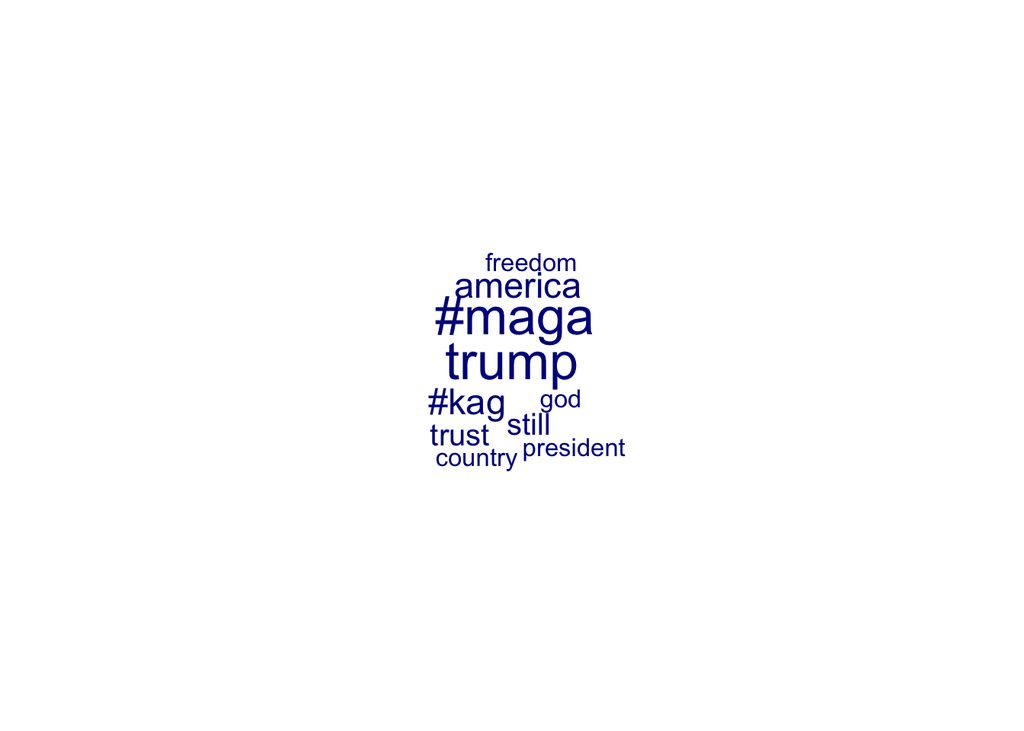

```r
# create table with frequency of word use
library(quanteda)
tw <- corpus(users$description[users$description!=""])
dfm <- dfm(tw, remove=c(stopwords("english"), stopwords("spanish"),
                                 "t.co", "https", "rt", "rts", "http"),
           remove_punct = TRUE)
# create wordcloud
par(mar=c(0,0,0,0))
textplot_wordcloud(dfm, rot.per=0, scale=c(3, .50), max.words=100)
```

5. And one final function to convert dates in their internal Twitter format to another format we could work with in R:

```r
# format Twitter dates to facilitate analysis
tweets <- parseTweets("data/realDonaldTrump.json")
```

```
## 1198 tweets have been parsed.
```

```r
tweets$date <- formatTwDate(tweets$created_at, format="date")
```

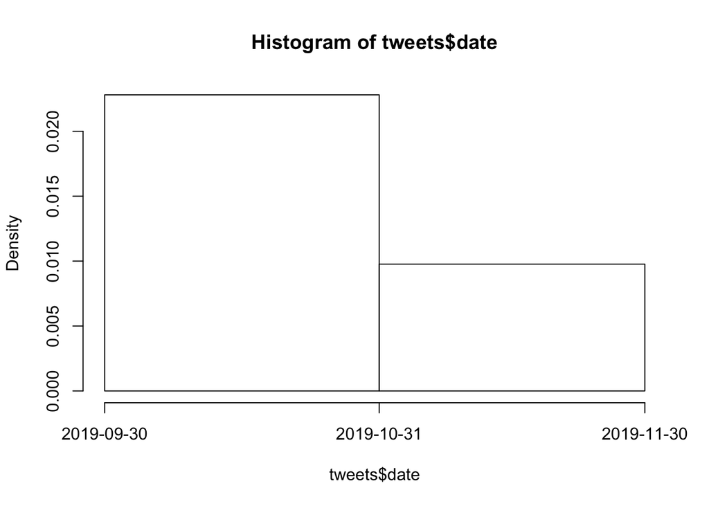

```r
hist(tweets$date, breaks="month")
```

### Checking for bots

A large proportion of Twitter accounts may be automated (bots). The Botometer API offers a way to check for sign of automation. The code below, adapted from the package by `@marsha5814` shows one way to interact with that API.

```r
botometer = function(user, my_oauth, mashape_key, verbose=TRUE) {
  require(httr)
  # creating OAuth token
  myapp = oauth_app("twitter", key=my_oauth$consumer_key,
                    secret=my_oauth$consumer_secret)
  sig = sign_oauth1.0(myapp, token=my_oauth$access_token,
                    token_secret=my_oauth$access_token_secret)

  users_url = "https://api.twitter.com/1.1/users/show.json?screen_name="
  statuses_url = "https://api.twitter.com/1.1/statuses/user_timeline.json?screen_name="
  search_url = "https://api.twitter.com/1.1/search/tweets.json?q=%40"
  opts = "&count=200"

  # API call to get user
  if (verbose) message("Downloading user profile...")
  userdata = GET(paste0(users_url,user,opts), sig)

  # API call to get tweets
  if (verbose) message("Downloading user tweets...")
  tweets = GET(paste0(statuses_url,user,opts), sig)

  # API call to get mentions
  if (verbose) message("Downloading user mentions...")
  mentions = GET(paste0(search_url,user,opts), sig)


  # Put everything in a list
  body = list(
    timeline = content(tweets, type="application/json"),
    mentions = content(mentions, type="application/json"),
    user = content(userdata, type="application/json")
  )

  # Convert to JSON
  body_json = RJSONIO::toJSON(body, auto_unbox = T, pretty = T)

  # Make the API request
  if (verbose) message("Checking Botometer scores...")
  result = POST("https://osome-botometer.p.mashape.com/2/check_account",
                 encode="json",
                 add_headers(`X-Mashape-Key`=mashape_key),
                 body=body_json)

  # Parse result
  result = content(result, as = "parsed")

  # Return "English" score
  return(result)
}


results <- botometer("uscpoir", my_oauth,
          mashape_key = 'Ujq7AAd3igmshqCBvI1LWbz0J8Hlp1hvVOYjsnMOx8z6bg4U68')
```

```
## Checking Botometer scores...
```

```r
results$scores
```

```
## $english
## [1] 0.4008614
##
## $universal
## [1] 0.3937465
```

```r
results$categories
```

```
## $content
## [1] 0.2225713
##
## $friend
## [1] 0.2837789
##
## $network
## [1] 0.1433867
##
## $sentiment
## [1] 0.2275003
##
## $temporal
## [1] 0.1050165
##
## $user
## [1] 0.3505041
```

```r
results <- botometer("realDonaldTrump", my_oauth,
          mashape_key = 'Ujq7AAd3igmshqCBvI1LWbz0J8Hlp1hvVOYjsnMOx8z6bg4U68')
```

```
## Checking Botometer scores...
```

```r
results$scores
```

```
## $english
## [1] 0.0254716
##
## $universal
## [1] 0.02991382
```

```r
results$categories
```

```
## $content
## [1] 0.04456565
##
## $friend
## [1] 0.1061262
##
## $network
## [1] 0.05015681
##
## $sentiment
## [1] 0.04955679
##
## $temporal
## [1] 0.1050165
##
## $user
## [1] 0.02781797
```

```r
results <- botometer("everyword", my_oauth,
          mashape_key = 'Ujq7AAd3igmshqCBvI1LWbz0J8Hlp1hvVOYjsnMOx8z6bg4U68')
```

```
## Checking Botometer scores...
```

```r
results$scores
```

```
## $english
## [1] 0.1684732
##
## $universal
## [1] 0.4950576
```

```r
results$categories
```

```
## $content
## [1] 0.1494079
##
## $friend
## [1] 0.5529005
##
## $network
## [1] 0.77706
##
## $sentiment
## [1] 0.5603273
##
## $temporal
## [1] 0.6278002
##
## $user
## [1] 0.07785929
```

```r
results <- botometer("Horse_3books", my_oauth,
          mashape_key = 'Ujq7AAd3igmshqCBvI1LWbz0J8Hlp1hvVOYjsnMOx8z6bg4U68')
```

```
## Checking Botometer scores...
```

```r
results$scores
```

```
## $english
## [1] 0.3039573
##
## $universal
## [1] 0.2837825
```

```r
results$categories
```

```
## $content
## [1] 0.4491906
##
## $friend
## [1] 0.5529005
##
## $network
## [1] 0.7201104
##
## $sentiment
## [1] 0.5106788
##
## $temporal
## [1] 0.5376446
##
## $user
## [1] 0.07248798
```